# Проверка гипотез. Классические статистические тесты

# Требования к сдаче и оформлению задания

Заполните этот qmd-файл кодом и текстовыми ответами. Порядок сдачи задания описан в `README.md`. Требования ниже действуют для всех заданий, даже если в отдельном пункте они не повторяются.

1. Соблюдайте единый стиль оформления и структуру отчёта. Не оставляйте лишние блоки кода, текст или комментарии, которые не относятся к решению задания.
2. Ответы на вопросы, обоснования выбора методов и интерпретации результатов пишите обычным текстом, а не комментариями к коду. Код и его вывод, таблицы и графики не заменяют ответ на вопрос. Замените заглушки `*(ответ студента)*` своими ответами.
3. Численные результаты представляйте в тексте или аккуратных таблицах с понятными подписями. Не оставляйте необработанный консольный вывод или отдельные числа без пояснений. Допускается сохранять стандартный вывод функций статистических тестов, но его необходимо сопровождать текстовой интерпретацией.
4. После каждой проверки гипотезы сформулируйте текстовый вывод: укажите p-значение, уровень значимости и решение об отклонении или неотклонении нулевой гипотезы. Ответьте на исследовательский вопрос. Если в задании требуется доверительный интервал, объясните его смысл. Различайте статистическую и практическую (клиническую) значимость эффекта.
5. Графики должны быть достаточно крупными, с читаемыми русскими подписями, содержательным заголовком и правильно названными осями. Где применимо, указывайте единицы измерения. Не используйте фон ggplot2 по умолчанию.
6. Сохраняйте исходную структуру проекта в репозитории. Не добавляйте лишние файлы, которые не относятся к проекту или выполнению заданий.
7. Оформление коммитов и веток на GitHub должно соответствовать общим правилам для всех курсов Института биоинформатики.

# Настройка

Загрузите необходимые пакеты и установите seed.

```r
library(tidyverse)
library(epitools)

set.seed(21)
```

## Загрузка и проверка данных

В этом упражнении мы будем использовать данные NHANES (Национальное обследование здоровья и питания населения США). Подробное описание исходного набора данных и его переменных: [документация NHANES](https://cran.r-project.org/web/packages/NHANES/refman/NHANES.html).

Прочитайте предоставленный файл с данными.

```r
data = read_csv("data/nhanes.csv")
```

Проверьте размер и структуру таблицы, типы переменных и наличие пропущенных значений. Убедитесь, что данные прочитаны корректно.

Подготовьте данные для выполнения заданий:

1. Оставьте столбцы `ID`, `Gender`, `Age`, `BMI`, `BPSysAve`, `BPDiaAve`, `PhysActive`, `SleepTrouble`, `Height`, `Weight`, `Education` и `HHIncome`.
2. Оставьте только участников в возрасте 18 лет и старше.
3. Для простоты задания удалите строки, в которых есть хотя бы одно пропущенное значение среди оставленных столбцов.
4. Проверьте типы переменных и при необходимости преобразуйте их. Для порядковых признаков убедитесь, что порядок категорий соответствует их смыслу, а не алфавитному порядку.

Сохраните подготовленную таблицу в объект `nhanes_clean`. Сколько строк было до подготовки и сколько осталось после неё?

```r
cat("Количество строк:", nrow(data), "\n")
```

```
Количество строк: 6779
```

```r
cat("Количество столбцов:", ncol(data), "\n")
```

```
Количество столбцов: 76
```

```r
glimpse(data)
```

```
Rows: 6,779
Columns: 76
$ ID               <dbl> 51624, 51625, 51630, 51638, 51646, 51647, 51654, 5165…
$ SurveyYr         <chr> "2009_10", "2009_10", "2009_10", "2009_10", "2009_10"…
$ Gender           <chr> "male", "male", "female", "male", "male", "female", "…
$ Age              <dbl> 34, 4, 49, 9, 8, 45, 66, 58, 54, 10, 58, 50, 9, 33, 6…
$ AgeDecade        <chr> "30-39", "0-9", "40-49", "0-9", "0-9", "40-49", "60-6…
$ AgeMonths        <dbl> 409, 49, 596, 115, 101, 541, 795, 707, 654, 123, 700,…
$ Race1            <chr> "White", "Other", "White", "White", "White", "White",…
$ Race3            <chr> NA, NA, NA, NA, NA, NA, NA, NA, NA, NA, NA, NA, NA, N…
$ Education        <chr> "High School", NA, "Some College", NA, NA, "College G…
$ MaritalStatus    <chr> "Married", NA, "LivePartner", NA, NA, "Married", "Mar…
$ HHIncome         <chr> "25000-34999", "20000-24999", "35000-44999", "75000-9…
$ HHIncomeMid      <dbl> 30000, 22500, 40000, 87500, 60000, 87500, 30000, 1000…
$ Poverty          <dbl> 1.36, 1.07, 1.91, 1.84, 2.33, 5.00, 2.20, 5.00, 2.20,…
```

[output cut: 63 more lines]

```r
colSums(is.na(data))
```

```
              ID         SurveyYr           Gender              Age
               0                0                0                0
       AgeDecade        AgeMonths            Race1            Race3
             249             3230                0             3568
       Education    MaritalStatus         HHIncome      HHIncomeMid
            2134             2129              585              585
         Poverty        HomeRooms          HomeOwn             Work
             518               48               44             1733
          Weight           Length         HeadCirc           Height
              55             6317             6702              298
             BMI BMICatUnder20yrs          BMI_WHO            Pulse
             304             5857              329             1127
        BPSysAve         BPDiaAve           BPSys1           BPDia1
            1137             1137             1352             1352
          BPSys2           BPDia2           BPSys3           BPDia3
            1278             1278             1280             1280
    Testosterone       DirectChol          TotChol        UrineVol1
            4218             1183             1183              791
      UrineFlow1        UrineVol2       UrineFlow2         Diabetes
            1218             5805             5806              126
     DiabetesAge        HealthGen  DaysPhysHlthBad  DaysMentHlthBad
            6322             1881             1888             1886
  LittleInterest        Depressed     nPregnancies          nBabies
            2509             2507             5083             5202
      Age1stBaby    SleepHrsNight     SleepTrouble       PhysActive
            5534             1744             1732             1334
  PhysActiveDays         TVHrsDay       CompHrsDay    TVHrsDayChild
            3702             3686             3683             6245
 CompHrsDayChild  Alcohol12PlusYr       AlcoholDay      AlcoholYear
            6245             2580             3713             3049
        SmokeNow         Smoke100        Smoke100n         SmokeAge
            4723             2125             2125             4807
       Marijuana    AgeFirstMarij     RegularMarij      AgeRegMarij
            3696             5053             3696             5952
       HardDrugs          SexEver           SexAge  SexNumPartnLife
            3164             3164             3325             3192
  SexNumPartYear          SameSex   SexOrientation      PregnantNow
            3705             3164             3770             5660
```

```r
nhanes <- select(
  data,
  ID, Gender, Age, BMI, BPSysAve, BPDiaAve,
  PhysActive, SleepTrouble, Height, Weight,
  Education, HHIncome
)

nhanes <- filter(nhanes, Age >= 18)

nhanes_clean <- drop_na(nhanes)
```

```r
cat("Количество участников:", nrow(nhanes_clean), "\n")
```

```
Количество участников: 4032
```

```r
cat("Количество переменных:", ncol(nhanes_clean), "\n")
```

```
Количество переменных: 12
```

# Тесты для непрерывных данных

## Параметрические тесты

### 1. Сравнение ИМТ с историческим средним

На основе исторических данных среднее значение ИМТ (`BMI`) для взрослых в США составляет **28.5**. ИМТ (индекс массы тела) рассчитывается как масса в килограммах, делённая на квадрат роста в метрах: $\mathrm{ИМТ} = \text{масса (кг)} / \text{рост (м)}^2$. Вопрос исследования: отличается ли среднее значение ИМТ в популяции взрослых (возраст ≥ 18) от исторического значения **28.5**?

#### Задание 1.1

Сформулируйте нулевую и альтернативную гипотезы.

- $H_0$: Среднее значение ИМТ среди взрослых жителей США равно историческому значению 28,5
- $H_a$: Среднее значение ИМТ среди взрослых жителей США не равно историческому значению 28,5

#### Задание 1.2

Посчитайте ключевые статистики (среднее, стандартное отклонение, размер выборки) для переменной `BMI` в вашем чистом наборе данных `nhanes_clean`.

```r
mean_bmi <- mean(nhanes_clean$BMI)
sd_bmi <- sd(nhanes_clean$BMI)
n_bmi <- length(nhanes_clean$BMI)

cat("Среднее значение BMI:", mean_bmi, "\n")
```

```
Среднее значение BMI: 28.99308
```

```r
cat("Стандартное отклонение:", sd_bmi, "\n")
```

```
Стандартное отклонение: 6.849808
```

```r
cat("Размер выборки:", n_bmi, "\n")
```

```
Размер выборки: 4032
```

#### Задание 1.3

Выберите подходящий статистический тест для проверки гипотез из задания 1.1 и объясните свой выбор.

Используем одновыборочный тест Стьюдента: проверяем, отличается ли среднее значение количественной переменной в одной выборке от заданного значения (исторического). Анализируется одна выборка, а популяционное стандартное отклонение неизвестно

#### Задание 1.4

Используя выбранный тест, проверьте гипотезы из задания 1.1 на уровне значимости α = 0.1.

```r
mu_0_bmi <- 28.5

t.test(nhanes_clean$BMI,
       mu = mu_0_bmi,
       alternative = "two.sided",
       conf.level = 0.90)
```

```
    One Sample t-test

data:  nhanes_clean$BMI
t = 4.5709, df = 4031, p-value = 5.003e-06
alternative hypothesis: true mean is not equal to 28.5
90 percent confidence interval:
 28.81560 29.17056
sample estimates:
mean of x
 28.99308
```

#### Задание 1.5

Как p-значение и 90% доверительный интервал информируют вас об общем статусе ИМТ этой популяции относительно среднего значения в общей популяции в 28.5? Что вы можете сказать про статистическую значимость?

Результаты теста показывают, что средний ИМТ исследуемой популяции статистически значимо выше исторического среднего значения 28,5. p-значение = 0,000005003 - но значительно меньше уровня значимости α = 0,1. Поэтому мы отвергаем нулевую гипотезу о равенстве среднего ИМТ значению 28,5. Полученные данные свидетельствуют о статистически значимом отличии среднего ИМТ. 90%-й доверительный интервал = [28,82; 29,17] полностью расположен выше 28,5, что указывает на более высокий средний ИМТ в исследуемой популяции.

### 2. Сравнение давления у мужчин и женщин

Сценарий: Исследователи хотят сравнить систолическое артериальное давление у мужчин и женщин. Вопрос исследования: есть ли статистически значимая разница в среднем систолическом артериальном давлении (`BPSysAve`) между **мужчинами** и **женщинами**?

#### Задание 2.1

Сформулируйте нулевую и альтернативную гипотезы.

- $H_0$: среднее систолическое давление у мужчин и женщин одинаковое
- $H_a$: среднее систолическое давление у мужчин и женщин различается

Подумайте, имеет ли значение, в какой группе давление больше.

Нет, так как мы проверяем гипотизу различается ли среднее и мужчин и женщин, или нет.

#### Задание 2.2

Посчитайте ключевые статистики (среднее в каждой группе, стандартное отклонение, размер каждой группы) для переменной `BPSysAve` в вашем чистом наборе данных `nhanes_clean`. Группы определяются переменной `Gender`.

```r
men <- filter(nhanes_clean, Gender == "male")
women <- filter(nhanes_clean, Gender == "female")

mean_men <- mean(men$BPSysAve)
sd_men <- sd(men$BPSysAve)
n_men <- nrow(men)

mean_women <- mean(women$BPSysAve)
sd_women <- sd(women$BPSysAve)
n_women <- nrow(women)

cat("Мужчины:\n")
```

```
Мужчины:
```

```r
cat("Среднее давление:", mean_men, "\n")
```

```
Среднее давление: 123.3359
```

```r
cat("Стандартное отклонение:", sd_men, "\n")
```

```
Стандартное отклонение: 15.87156
```

```r
cat("Размер группы:", n_men, "\n\n")
```

```
Размер группы: 1983
```

```r
cat("Женщины:\n")
```

```
Женщины:
```

```r
cat("Среднее давление:", mean_women, "\n")
```

```
Среднее давление: 119.1742
```

```r
cat("Стандартное отклонение:", sd_women, "\n")
```

```
Стандартное отклонение: 18.2874
```

```r
cat("Размер группы:", n_women, "\n")
```

```
Размер группы: 2049
```

#### Задание 2.3

Выберите подходящий статистический тест для проверки гипотез из задания 2.1 и объясните свой выбор.

Выберем двувыборочный т-критерий Стьюдента (тест Вэлча). Мы сравниваем две независимые группы (мужчин и женщин), сравнивается количественная характеристика, стандартные отклонения групп отличаются, а популяционные стандартные отклонения неизвестны.

#### Задание 2.4

Используя выбранный тест, проверьте гипотезы из задания 2.1 на уровне значимости α = 0.1.

```r
t.test(men$BPSysAve,
       women$BPSysAve,
       alternative = "two.sided",
       conf.level = 0.90)
```

```
    Welch Two Sample t-test

data:  men$BPSysAve and women$BPSysAve
t = 7.7246, df = 3983.3, p-value = 1.41e-14
alternative hypothesis: true difference in means is not equal to 0
90 percent confidence interval:
 3.275257 5.047990
sample estimates:
mean of x mean of y
 123.3359  119.1742
```

#### Задание 2.5

Как p-значение и 90% доверительный интервал информируют вас о разнице измеренного артериального давления между мужчинами и женщинами? Что вы можете сказать про статистическую значимость?

Результаты теста показывают статистически значимые различия в среднем систолическом артериальном давлении между мужчинами и женщинами (поскольку p-значение = 1.41e-14 значительно меньше уровня значимости α = 0,1, нулевая гипотеза отвергается). Среднее систолическое давление мужчин составляет 123,34 мм рт. ст., женщин - 119,17 мм рт. ст. Таким образом, в исследуемой выборке среднее давление мужчин выше примерно на 4,16. 90%-й доверительный интервал разницы средних составляет [3,28; 5,05] мм рт. ст. и не включает ноль, что также подтверждает наличие статистически значимых различий.

### 3. Сравнение систолического и диастолического давления

Сценарий: Измерения систолического (`BPSysAve`) и диастолического (`BPDiaAve`) давления не являются независимыми. Вопрос исследования: равна ли нулю средняя **разница** между систолическим (`BPSysAve`) и диастолическим (`BPDiaAve`) давлением (пульсовое давление) в исследуемой популяции?

#### Задание 3.1

Сформулируйте нулевую и альтернативную гипотезы.

- $H_0$: средняя разница между систолическим и диастолическим давлением в исследуемой популяции равна нулю
- $H_a$: средняя разница между систолическим и диастолическим давлением в исследуемой популяции не равна нулю

Подумайте, имеет ли значение, в какой группе давление больше.

Нет, тк вопрос существует ли разница между группами вообще, а не какая она.

#### Задание 3.2

Посчитайте ключевые статистики для переменных `BPSysAve` и `BPDiaAve` в вашем чистом наборе данных `nhanes_clean`.

```r
mean_sys <- mean(nhanes_clean$BPSysAve)
sd_sys <- sd(nhanes_clean$BPSysAve)
n_sys <- sum(!is.na(nhanes_clean$BPSysAve))

mean_dia <- mean(nhanes_clean$BPDiaAve)
sd_dia <- sd(nhanes_clean$BPDiaAve)
n_dia <- sum(!is.na(nhanes_clean$BPDiaAve))

cat("Систолическое давление:\n")
```

```
Систолическое давление:
```

```r
cat("Среднее значение:", mean_sys, "\n")
```

```
Среднее значение: 121.221
```

```r
cat("Стандартное отклонение:", sd_sys, "\n")
```

```
Стандартное отклонение: 17.26558
```

```r
cat("Размер выборки:", n_sys, "\n\n")
```

```
Размер выборки: 4032
```

```r
cat("Диастолическое давление:\n")
```

```
Диастолическое давление:
```

```r
cat("Среднее значение:", mean_dia, "\n")
```

```
Среднее значение: 69.92336
```

```r
cat("Стандартное отклонение:", sd_dia, "\n")
```

```
Стандартное отклонение: 12.75247
```

```r
cat("Размер выборки:", n_dia, "\n")
```

```
Размер выборки: 4032
```

**Дополнительно (необязательное задание)** Визуализируйте эти параметры. Используйте боксплот, свяжите линиями измерения одного пациента.

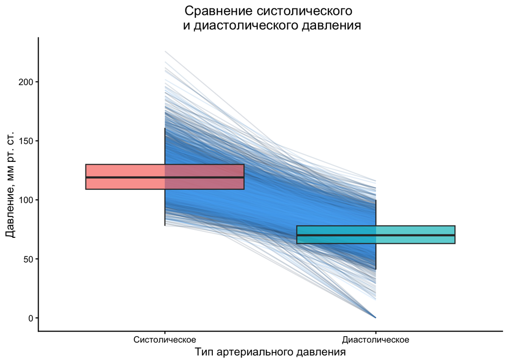

```r
pressure_long <- pivot_longer(
  nhanes_clean,
  cols = c(BPSysAve, BPDiaAve),
  names_to = "PressureType",
  values_to = "Pressure"
)

pressure_long$PressureType <- factor(
  pressure_long$PressureType,
  levels = c("BPSysAve", "BPDiaAve"),
  labels = c("Систолическое", "Диастолическое")
)

ggplot(pressure_long, aes(x = PressureType, y = Pressure)) +
  geom_line(aes(group = ID, color = ID), alpha = 0.15, show.legend = FALSE) +
  geom_boxplot(aes(fill = PressureType), alpha = 0.7, outlier.shape = NA) +
  labs(
    title = "Сравнение систолического \n и диастолического давления",
    x = "Тип артериального давления",
    y = "Давление, мм рт. ст."
  ) +
  theme_classic() +
  theme(
    legend.position = "none",
    plot.title = element_text(hjust = 0.5)
  )
```

#### Задание 3.3

Выберите подходящий статистический тест для проверки гипотез из задания 3.1 и объясните свой выбор.

#### Задание 3.4

Используя выбранный тест, проверьте гипотезы из задания 3.1 на уровне значимости α = 0.1.

```r
t.test(nhanes_clean$BPSysAve,
       nhanes_clean$BPDiaAve,
       paired = TRUE,
       alternative = "two.sided",
       conf.level = 0.90)
```

```
    Paired t-test

data:  nhanes_clean$BPSysAve and nhanes_clean$BPDiaAve
t = 181.21, df = 4031, p-value < 2.2e-16
alternative hypothesis: true mean difference is not equal to 0
90 percent confidence interval:
 50.83189 51.76335
sample estimates:
mean difference
       51.29762
```

#### Задание 3.5

Как p-значение и 90% доверительный интервал информируют вас о разнице измеренного систолического и диастолического артериального давления? Что вы можете сказать про статистическую значимость?

p-значение<2.2e-16 - значительно меньше уровня значимости α = 0,1. Нулевую гипотезу отвергаем. Средняя разница составляет 51,30 мм рт. ст. 90%-й доверительный интервал: [50,83; 51,76] мм рт. ст. Он не включает ноль, что подтверждает статистическую значимость различия.

## Непараметрические тесты

Допустим, мы хотим сравнить статистическое доминирование ИМТ, а не средние абсолютные значения.

### 4. Сравнение ИМТ мужчин и женщин при помощи непараметрических тестов

Вопрос исследования: можно ли сказать, что значения ИМТ (`BMI`) у представителей одного пола, как правило, выше, чем у представителей другого?

#### Задание 4.1

Сформулируйте нулевую и альтернативную гипотезы.

Посчитайте ключевые статистики (количество пациентов в каждой группе и другие статистики по необходимости).

```r
men <- filter(nhanes_clean, Gender == "male", !is.na(BMI))
women <- filter(nhanes_clean, Gender == "female", !is.na(BMI))

n_men <- nrow(men)
n_women <- nrow(women)

cat("Количество мужчин:", n_men, "\n")
```

```
Количество мужчин: 1983
```

```r
cat("Количество женщин:", n_women, "\n")
```

```
Количество женщин: 2049
```

Объясните, почему выбор статистик отличается для этого сценария от сценариев 1, 2 и 3.

Мы использовали параметрические тесты, где сравниваются средние - поэтому нужны были среднее и стандартное отклонение. Тут используется критерий Манна-Уитни. Он сравнивает ранги наблюдений в двух независимых группах, а не непосредственно средние значения. Поэтому для подготовки к тесту достаточно знать количество наблюдений и сами значения ИМТ.

#### Задание 4.3

Выберите подходящий статистический тест для проверки гипотез из задания 4.1 и объясните свой выбор. Имеет ли значение для выбора теста, сколько пациентов в каждой группе?

Являются ли группы зависимыми или независимыми?

Используем непараметрический критерий Манна — Уитни 1) Две независимые группы (муж и жен) 2) Количественные значения 3) Сравнения рангов (отличаются ли распределения)

#### Задание 4.4

Проверьте гипотезы из задания 4.1 на уровне значимости α = 0.1.

```r
wilcox.test(men$BMI,
            women$BMI,
            alternative = "two.sided",
            paired = FALSE,
            conf.int = TRUE,
            conf.level = 0.90)
```

```
    Wilcoxon rank sum test with continuity correction

data:  men$BMI and women$BMI
W = 2054564, p-value = 0.534
alternative hypothesis: true location shift is not equal to 0
90 percent confidence interval:
 -0.1999960  0.4299661
sample estimates:
difference in location
             0.1100318
```

#### Задание 4.5

На основании полученного p-значения сделайте вывод о различии между группами. Что вы можете сказать про статистическую значимость?

p-значение = 0,534 и превышает уровень значимости α = 0,1. Нулевая гипотеза не отвергается. Статистически значимых различий в распределении ИМТ между мужчинами и женщинами не обнаружено. На основании полученных данных нельзя утверждать, что у представителей одного пола значения ИМТ обычно выше, чем у представителей другого.

### 5. Сравнение систолического и диастолического давления

Вопрос исследования: превосходят ли, как правило, значения одного типа артериального давления значения другого типа (САД и ДАД)? САД – систолическое артериальное давление, ДАД – диастолическое артериальное давление.

#### Задание 5.1

Сформулируйте нулевую и альтернативную гипотезы.

- $H_0$: средняя разница между систолическим и диастолическим давлением равна нулю
- $H_a$: средняя разница между систолическим и диастолическим давлением не равна нулю

#### Задание 5.2

Посчитайте ключевые статистики для переменных `BPSysAve` и `BPDiaAve` в вашем чистом наборе данных `nhanes_clean`. Обратите внимание, что это иные статистики, чем в задании 3.

```r
median_sys <- median(nhanes_clean$BPSysAve, na.rm = TRUE)
q1_sys <- quantile(nhanes_clean$BPSysAve, 0.25, na.rm = TRUE)
q3_sys <- quantile(nhanes_clean$BPSysAve, 0.75, na.rm = TRUE)
n_sys <- sum(!is.na(nhanes_clean$BPSysAve))

median_dia <- median(nhanes_clean$BPDiaAve, na.rm = TRUE)
q1_dia <- quantile(nhanes_clean$BPDiaAve, 0.25, na.rm = TRUE)
q3_dia <- quantile(nhanes_clean$BPDiaAve, 0.75, na.rm = TRUE)
n_dia <- sum(!is.na(nhanes_clean$BPDiaAve))

cat("Систолическое давление:\n")
```

```
Систолическое давление:
```

```r
cat("Медиана:", median_sys, "\n")
```

```
Медиана: 119
```

```r
cat("Первый квартиль:", q1_sys, "\n")
```

```
Первый квартиль: 109
```

```r
cat("Третий квартиль:", q3_sys, "\n")
```

```
Третий квартиль: 130
```

```r
cat("Размер выборки:", n_sys, "\n\n")
```

```
Размер выборки: 4032
```

```r
cat("Диастолическое давление:\n")
```

```
Диастолическое давление:
```

```r
cat("Медиана:", median_dia, "\n")
```

```
Медиана: 70
```

```r
cat("Первый квартиль:", q1_dia, "\n")
```

```
Первый квартиль: 63
```

```r
cat("Третий квартиль:", q3_dia, "\n")
```

```
Третий квартиль: 78
```

```r
cat("Размер выборки:", n_dia, "\n")
```

```
Размер выборки: 4032
```

**Дополнительно (необязательное задание)** Визуализируйте эти параметры. Используйте скрипичный график и боксплот, свяжите линиями измерения одного пациента. Визуально оцените, как выглядит распределение обеих переменных.

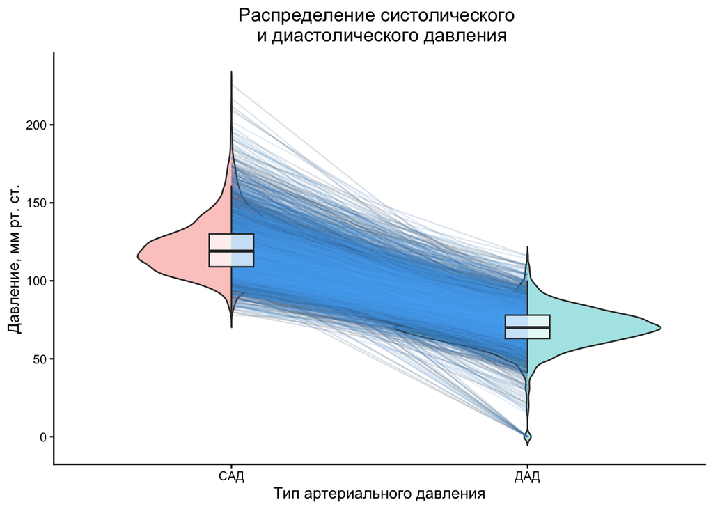

```r
pressure_long <- pivot_longer(
  nhanes_clean,
  cols = c(BPSysAve, BPDiaAve),
  names_to = "PressureType",
  values_to = "Pressure"
)

pressure_long$PressureType <- factor(
  pressure_long$PressureType,
  levels = c("BPSysAve", "BPDiaAve"),
  labels = c("САД", "ДАД")
)

ggplot(pressure_long, aes(x = PressureType, y = Pressure)) +
  geom_violin(aes(fill = PressureType), alpha = 0.4, trim = FALSE) +
  geom_line(aes(group = ID, color = ID), alpha = 0.15,
            show.legend = FALSE) +
  geom_boxplot(width = 0.15, outlier.shape = NA, alpha = 0.7) +
  labs(
    title = "Распределение систолического \n и диастолического давления",
    x = "Тип артериального давления",
    y = "Давление, мм рт. ст."
  ) +
  theme_classic() +
  theme(
    legend.position = "none",
    plot.title = element_text(hjust = 0.5)
  )
```

#### Задание 5.3

Выберите подходящий статистический тест для проверки гипотез из задания 5.1 и объясните свой выбор.

Используем Wilcoxon signed-rank test 1) САД и ДАД измерены у одних и тех же участников, поэтому выборки зависимые (парные) 2) Обе переменные количественные. 3)Мы хотим сравнить два связанных измерения и проверить, отличаются ли они систематически.

#### Задание 5.4

Используя выбранный тест, проверьте гипотезы из задания 5.1 на уровне значимости α = 0.1.

```r
wilcox.test(nhanes_clean$BPSysAve,
            nhanes_clean$BPDiaAve,
            paired = TRUE,
            alternative = "two.sided",
            conf.int = TRUE,
            conf.level = 0.90)
```

```
    Wilcoxon signed rank test with continuity correction

data:  nhanes_clean$BPSysAve and nhanes_clean$BPDiaAve
V = 8130528, p-value < 2.2e-16
alternative hypothesis: true location shift is not equal to 0
90 percent confidence interval:
 48.99998 49.50000
sample estimates:
(pseudo)median
      49.00002
```

#### Задание 5.5

На основании полученного p-значения сделайте вывод о различии между систолическим и диастолическим артериальным давлением. Что вы можете сказать про статистическую значимость?

Полученное p-значение < 2.2e-16, что значительно меньше уровня значимости α = 0,1. Следовательно, нулевая гипотеза отвергается. Между систолическим и диастолическим артериальным давлением обнаружено статистически значимое различие. Систолическое давление, как правило, выше диастолического.

# Тесты для категориальных данных

### 6. Поиск зависимости между физической активностью и проблемами со сном

Вы хотите исследовать, есть ли взаимосвязь между проблемами со сном у человека и тем, занимается ли он физической активностью. Переменные: `PhysActive` — бинарный признак (`Yes` = занимается физической активностью, `No` = не занимается), `SleepTrouble` — бинарный признак (`Yes` = есть проблемы со сном, `No` = нет проблем).

#### Задание 6.1

Сформулируйте нулевую и альтернативную гипотезы для проверки связи между физической активностью и проблемами со сном. Какую альтернативу вы используете – одностороннюю или двустороннюю? Обоснуйте ответ

- $H_0$: Физическая активность и наличие проблем со сном независимы. Между этими переменными нет статистически значимой связи.
- $H_a$: Физическая активность и наличие проблем со сном зависимы. Между этими переменными есть статистически значимая связь.

#### Задание 6.2

Постройте таблицу сопряженности и визуализируйте ее. Исходя из полученной таблицы и иллюстрации, как вам кажется, похожи ли наши признаки на независимые? Почему?

```r
sleep_activity_table <- table(
  nhanes_clean$PhysActive,
  nhanes_clean$SleepTrouble
)

sleep_activity_table
```

```
        No  Yes
  No  1405  531
  Yes 1582  514
```

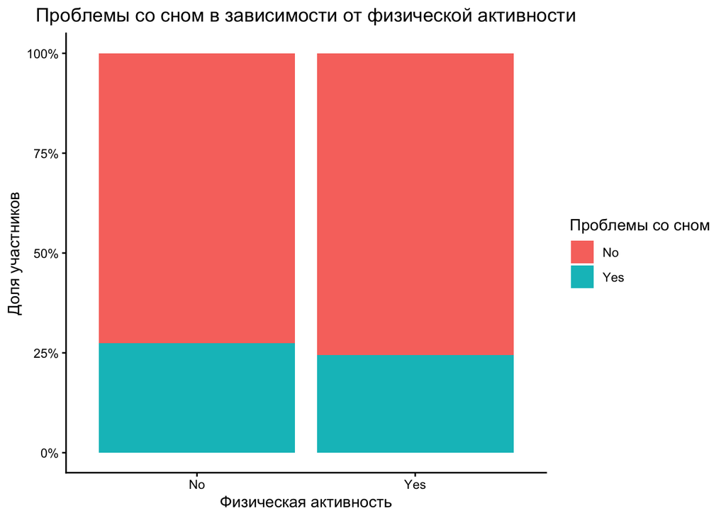

```r
sleep_activity_data <- as.data.frame(
  prop.table(sleep_activity_table, margin = 1)
)

colnames(sleep_activity_data) <- c(
  "Физическая активность",
  "Проблемы со сном",
  "Доля"
)

ggplot(sleep_activity_data,
       aes(x = `Физическая активность`,
           y = Доля,
           fill = `Проблемы со сном`)) +
  geom_col(position = "stack") +
  labs(
    title = "Проблемы со сном в зависимости от физической активности",
    x = "Физическая активность",
    y = "Доля участников",
    fill = "Проблемы со сном"
  ) +
  scale_y_continuous(labels = scales::percent) +
  theme_classic() +
  theme(
    plot.title = element_text(hjust = 0.5)
  )
```

Распределние выглядит одинаковым, поэтому, скорее всего влияния на физической активности на сон нет.

#### Задание 6.3

Какой статистический тест подходит для тестирования гипотезы из задания 6.1 (Хи-квадрат, Фишер, МакНемара)? Объясните свой выбор. Какие ограничения у выбранного теста? Если нужно, проверьте ограничения.

Для проверки гипотез используется критерий хи-квадрат Пирсона на независимость, поскольку обе исследуемые переменные - категориальные и имеют по два значения: `PhysActive` (Yes и No) и `SleepTrouble` (Yes и No). Критерий позволяет определить, существует ли статистически значимая связь между двумя категориальными переменными.

#### Задание 6.4

Используя выбранный тест, проверьте гипотезы из задания 6.1 на уровне значимости α = 0.05. Какое p-значение и значение статистики критерия получилось? Что вы можете сказать про статистическую значимость?

Совпадает ли результат статистического анализа с вашим предположением в задании 6.2? Если нет, попробуйте объяснить почему.

```r
chisq_result <- chisq.test(sleep_activity_table)

chisq_result
```

```
    Pearson's Chi-squared test with Yates' continuity correction

data:  sleep_activity_table
X-squared = 4.2728, df = 1, p-value = 0.03873
```

p-значение = 0.03873 меньше выбранного уровня значимости α = 0.05, нулевая гипотеза об независимости физической активности и наличия проблем со сном отвергается. Таким образом, обнаружена статистически значимая связь между физической активностью и проблемами со сном в исследуемой выборке.

Визуальное предположение не совпало с результатом статистического теста. На графике различия могут быть практически незаметны, но статистический тест учитывает количество наблюдений и способен выявить небольшие различия, которые сложно оценить по графику.

#### Задание 6.5

Посчитайте размер эффекта (отношение шансов и отношение рисков, если это имеет смысл для этого исследования) двумя способами – самостоятельно (посчитайте дроби исходя из таблицы сопряженности), и с помощью пакета epitools, сравните результаты. Проинтерпретируйте результат с точки зрения клинической значимости (не забудьте про 95% доверительный интервал!). Прокомментируйте, почему вы решили считать или не считать отношение рисков.

```r
sleep_activity_table <- table(
  factor(nhanes_clean$PhysActive, levels = c("Yes", "No")),
  factor(nhanes_clean$SleepTrouble, levels = c("Yes", "No"))
)

sleep_activity_table
```

```
       Yes   No
  Yes  514 1582
  No   531 1405
```

```r
a <- sleep_activity_table[1, 1]
b <- sleep_activity_table[1, 2]
c <- sleep_activity_table[2, 1]
d <- sleep_activity_table[2, 2]

OR <- (a * d) / (b * c)

PR <- (a / (a + b)) / (c / (c + d))

OR_epitools <- oddsratio(sleep_activity_table, method = "wald")
PR_epitools <- riskratio(sleep_activity_table, method = "wald")

effect_table <- data.frame(
  Показатель = c("OR", "PR"),
  Самостоятельный_расчет = c(OR, PR),
  epitools = c(
    OR_epitools$measure["No", "estimate"],
    PR_epitools$measure["No", "estimate"]
  ),
  Нижняя_граница_95_ДИ = c(
    OR_epitools$measure["No", "lower"],
    PR_epitools$measure["No", "lower"]
  ),
  Верхняя_граница_95_ДИ = c(
    OR_epitools$measure["No", "upper"],
    PR_epitools$measure["No", "upper"]
  )
)

effect_table
```

```
  Показатель Самостоятельный_расчет  epitools Нижняя_граница_95_ДИ
1         OR              0.8596832 0.8596832            0.7466537
2         PR              0.8940930 0.9615144            0.9268855
  Верхняя_граница_95_ДИ
1             0.9898232
2             0.9974370
```

отношение шансов (OR) составило 0,8597 с 95%-м доверительным интервалом [0,7467; 0,9898]. Это означает, что шансы наличия проблем со сном у физически активных участников примерно на 14% ниже, чем у участников без физической активности.

Отношение рисков (Risk Ratio, RR) в данном исследовании я не стал интерпретировать как классическое отношение рисков возникновения события, поскольку в этом исследовании оценивается распространённость проблем со сном в определённый период, а не возникновение новых случаев за период наблюдения. Поэтому для этих данных более подходящим показателем является отношение распространённостей (Prevalence Ratio, PR).

#### Задание 6.6

Исходя из результатов статистического анализа, можем ли мы сделать вывод, что физическая активность улучшает сон? Или что люди, которые лучше спят, чаще занимаются спортом?

Нет, однозначно сделать ни один из этих выводов мы не можем. Анализ выявил статистическую связь между физической активностью и проблемами со сном, но не установил причинно-следственную зависимость. Необходимы дополнительные исследования.

# Поиск зависимостей между количественными / порядковыми признаками

### 7. Анализ зависимости между ростом и массой тела

Вопрос исследования: есть ли линейная связь между ростом (`Height`) и массой тела (`Weight`) у участников NHANES в возрасте 18 лет и старше?

#### Задание 7.1

Сформулируйте нулевую и альтернативную гипотезы.

- $H_0$: линейная связь между ростом и массой тела отсутствует
- $H_a$: линейная связь между ростом и массой тела существует

#### Задание 7.2

Визуализируйте распределения анализируемых переменных. Визуально оцените форму распределений и наличие выбросов.

Постройте диаграмму рассеяния роста (`Height`) и массы тела (`Weight`) (график должен быть читаемым), оцените линейность связи признаков.

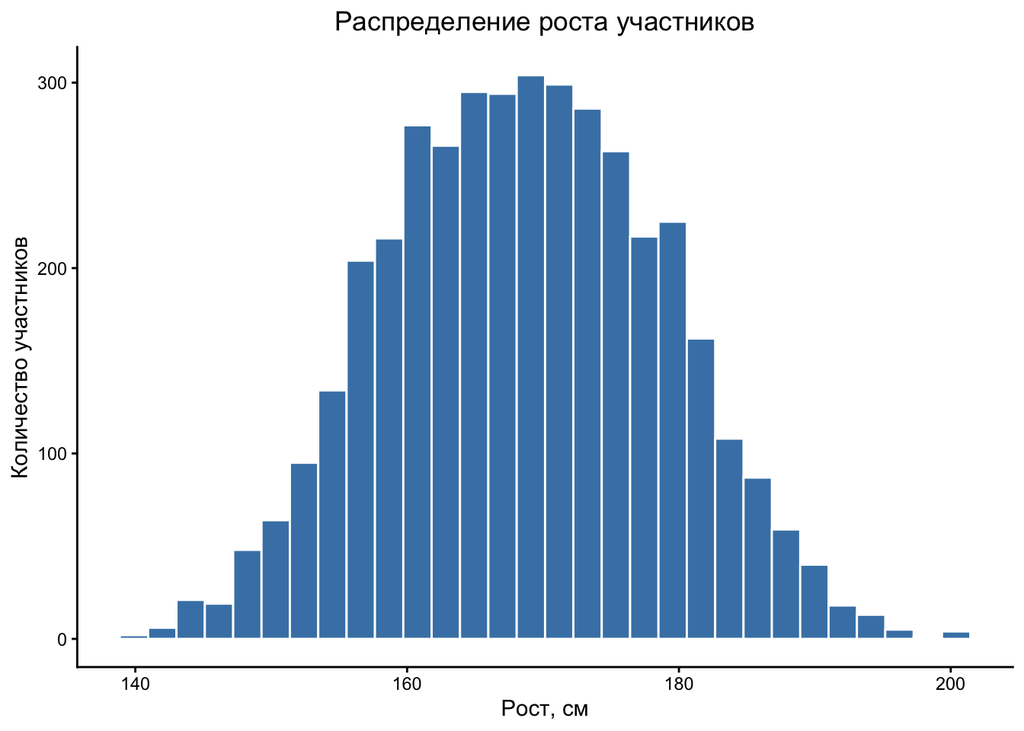

```r
height_weight <- filter(
  nhanes_clean,
  Age >= 18,
  !is.na(Height),
  !is.na(Weight)
)

ggplot(height_weight, aes(x = Height)) +
  geom_histogram(
    bins = 30,
    fill = "steelblue",
    color = "white"
  ) +
  labs(
    title = "Распределение роста участников",
    x = "Рост, см",
    y = "Количество участников"
  ) +
  theme_classic() +
  theme(
    plot.title = element_text(hjust = 0.5)
  )
```

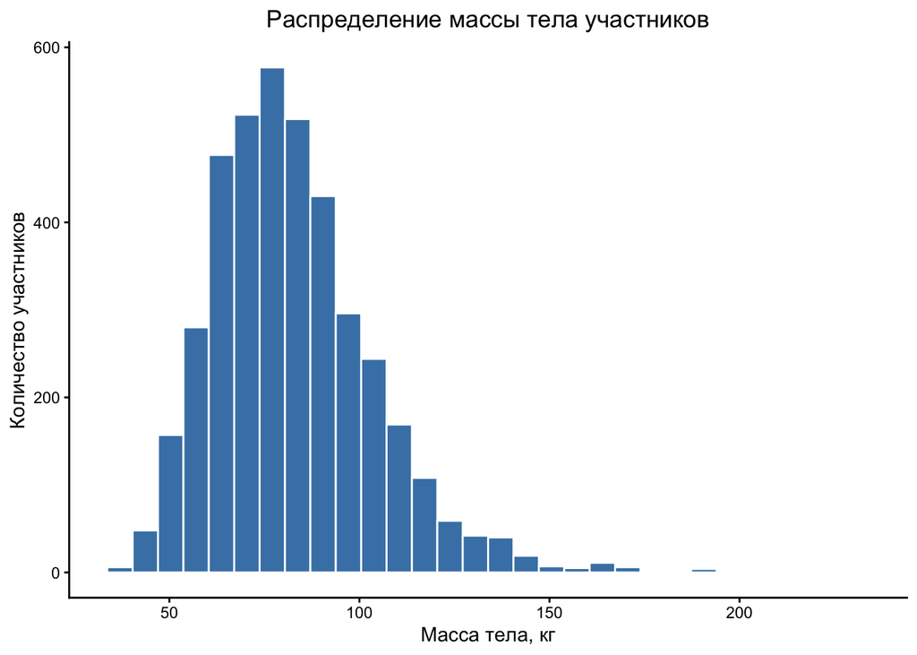

```r
ggplot(height_weight, aes(x = Weight)) +
  geom_histogram(
    bins = 30,
    fill = "steelblue",
    color = "white"
  ) +
  labs(
    title = "Распределение массы тела участников",
    x = "Масса тела, кг",
    y = "Количество участников"
  ) +
  theme_classic() +
  theme(
    plot.title = element_text(hjust = 0.5)
  )
```

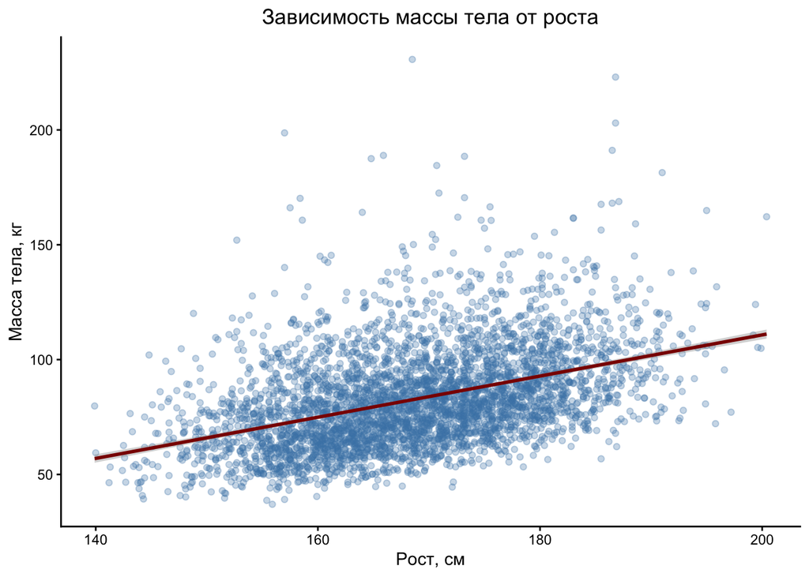

```r
ggplot(height_weight, aes(x = Height, y = Weight)) +
  geom_point(
    alpha = 0.3,
    color = "steelblue"
  ) +
  geom_smooth(
    method = "lm",
    se = TRUE,
    color = "darkred"
  ) +
  labs(
    title = "Зависимость массы тела от роста",
    x = "Рост, см",
    y = "Масса тела, кг"
  ) +
  theme_classic() +
  theme(
    plot.title = element_text(hjust = 0.5)
  )
```

Распределения роста имеет 1 вершину и колокообразную форму.

Распределение массы тела имеет выраженную правостороннюю асимметрию: большинство наблюдений сосредоточено в диапазоне примерно 55–100 кг, но присутствует длинный правый хвост и отдельные высокие значения.

На диаграмме рассеяния видна положительная зависимость между ростом и массой тела: с увеличением роста масса тела увеличивается. Расположение точек в целом соответствует линейной зависимости, хотя наблюдается значительный разброс значений и присутствуют отдельные выбросы.

Исходя из графиков, можно предположить наличие положительной линейной связи между ростом и массой тела.

#### Задание 7.3

Выберите подходящий статистический тест для проверки гипотезы из задания 7.1 и объясните свой выбор.

Используя выбранный тест, проверьте гипотезы из задания 7.1 на уровне значимости α = 0.05.

Оцените величину наблюдаемого эффекта.

```r
cor_test <- cor.test(
  height_weight$Height,
  height_weight$Weight,
  method = "pearson",
  alternative = "two.sided",
  conf.level = 0.95
)
r <- cor_test$estimate
r_squared <- r^2

cat("Коэффициент корреляции Пирсона (r):", r, "\n")
```

```
Коэффициент корреляции Пирсона (r): 0.4244803
```

```r
cat("p-значение", cor_test$p.value, "\n")
```

```
p-значение 4.073048e-176
```

```r
cat("Коэффициент детерминации:", r_squared, "\n")
```

```
Коэффициент детерминации: 0.1801836
```

Используем коэффициент корреляции Пирсона и соответсвующий тест значимости корреляции. Берем его, так как тест как раз проверяет линейную зависимость (а диаграмма рассеивания показывает линейную зависимость), кроме того, наблюдения независимы. Однако стоит заметить, что распределение массы тела имеют ассиметрию, и присутсуют выбросы. Поэтому интерпретировать результаты необходимо будет аккуратнее.

Коэффициент детерминации примерно 0.1801836 - линейная модель роста и массы тела описывает около 18% вариации массы тела, остальное описывают другие метрики или индивидуальные особенности.

#### Задание 7.4

Как p-значение и 95% доверительный интервал информируют вас о силе и направлении связи между ростом и весом? Что вы можете сказать про статистическую и практическую значимость результата?

Квадрат коэффициента корреляции указывает, что линейная модель описывает около 18% вариации массы тела. То есть рост связан с массой тела, но не объясняет большую часть различий в массе тела. На нее также могут влиять другие факторы, например пол, возраст, образ жизни и др.

### 8. Анализ зависимости между образованием и доходом

Вопрос исследования: существует ли связь между уровнем образования (`Education`) и доходом домохозяйства (`HHIncome`) у участников NHANES в возрасте 18 лет и старше?

#### Задание 8.1

Сформулируйте нулевую и альтернативную гипотезы.

- $H_0$: связь между уровнем образования и доходом домохозяйства отсутствует
- $H_a$: связь между уровнем образования и доходом домохозяйства существует

#### Задание 8.2

Постройте диаграмму рассеяния, которая позволит визуализировать связь между изучаемыми переменными.

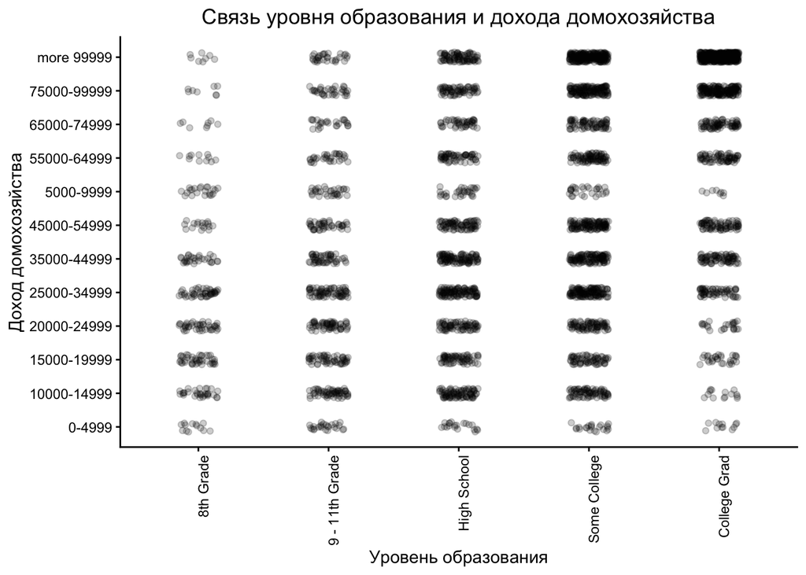

```r
education_income <- filter(
  nhanes_clean,
  Age >= 18,
  !is.na(Education),
  !is.na(HHIncome)
)

education_income$Education <- factor(
  education_income$Education,
  levels = c(
    "8th Grade",
    "9 - 11th Grade",
    "High School",
    "Some College",
    "College Grad"
  )
)

ggplot(education_income, aes(x = Education, y = HHIncome)) +
  geom_jitter(
    width = 0.15,
    height = 0.15,
    alpha = 0.2
  ) +
  labs(
    title = "Связь уровня образования и дохода домохозяйства",
    x = "Уровень образования",
    y = "Доход домохозяйства"
  ) +
  theme_classic() +
  theme(
    plot.title = element_text(hjust = 0.5),
    axis.text.x = element_text(angle = 90, hjust = 1)
  )
```

На графике можно заметить положительную связь: среди участников с более высоким уровнем образования чаще встречаются более высокие доходы домохозяйства. Однако есть и участники с высоким образованием и низким доходом, поэтому зависимость не однозначна.

#### Задание 8.3

Выберите подходящий статистический тест для проверки гипотезы из задания 8.1 и объясните свой выбор.

Используя выбранный тест, проверьте гипотезы из задания 8.1 на уровне значимости α = 0.05.

Оцените величину наблюдаемого эффекта.

```r
education_income$Education <- factor(
  education_income$Education,
  levels = c(
    "8th Grade",
    "9 - 11th Grade",
    "High School",
    "Some College",
    "College Grad"
  ),
  ordered = TRUE
)

education_income$HHIncome <- factor(
  education_income$HHIncome,
  levels = c(
    "0-4999",
    "5000-9999",
    "10000-14999",
    "15000-19999",
    "20000-24999",
    "25000-34999",
    "35000-44999",
    "45000-54999",
    "55000-64999",
    "65000-74999",
    "75000-99999",
    "more 99999"
  ),
  ordered = TRUE
)

spearman_test <- cor.test(
  as.numeric(education_income$Education),
  as.numeric(education_income$HHIncome),
  method = "spearman",
  alternative = "two.sided",
  exact = FALSE
)

spearman_test
```

```
    Spearman's rank correlation rho

data:  as.numeric(education_income$Education) and as.numeric(education_income$HHIncome)
S = 6087144201, p-value < 2.2e-16
alternative hypothesis: true rho is not equal to 0
sample estimates:
    rho
0.44281
```

Выберем ранговый коэффициент корреляции Спирмена, тк исследуется связь одной ранговой переменной (Education) сравнивается с другой (HHIncome). Помимо этого оценивается монотонная связь: увеличивается ли доход домохозяйства при повышении уровня образования.

Перед расчётом необходимо правильно упорядочить уровни обеих переменных.

Значение rho = 0.44281 и p-значение < 2.2e-16, что значит статистически значимая умеренная положительная монотонная связь между образованием и доходом домохозяйства (более высокому уровню образования в целом соответствует более высокий доход домохозяйства, однако уровень образования не определяет доход полностью). Нулевую гипотезу отвергаем.

#### Задание 8.4

Как p-значение и значение коэффициента корреляции информируют вас о силе и направлении связи между уровнем образования и доходом домохозяйства? Что вы можете сказать про статистическую и практическую значимость результата?

rho коэффициент указывает на прямую связь: при повышении уровня образования доход домохозяйства в целом также имеет тенденцию увеличиваться. Однако rho = 0.44281, что значит, что связь заметная, но не очень сильная - умеренная. p-значение < 2.2e-16, что значительно меньше уровня значимости α = 0.05. Поэтому нулевая гипотеза об отсутствии связи между уровнем образования и доходом домохозяйства отвергается.

Тк сила связи умеренная, что уровень образования связан с доходом домохозяйства, но не объясняет все различия в доходах. На доход также могут влиять и другие факторы: профессия, опыт работы, регион проживания и др.